# Statistics 744, McMaster University

# further principles of data visualization

## we recommend …

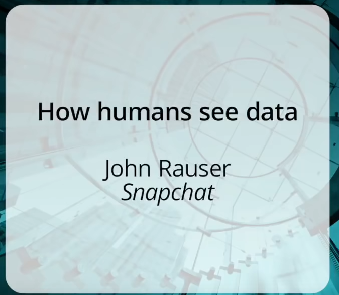

Rauser (2016)

[figure not shown]

Wilke (2019)

## Source code

https://github.com/mac-theobio/DataViz/blob/main/lectures/rtea_principles.rmd

## Packages

```
library(ggplot2); theme_set(theme_bw())
zmargin <- theme(panel.spacing=grid::unit(0,"lines"))
library(ggthemes)  ## tufteboxplot, scale_*_colourblind
library(directlabels)
library(ggpubr)
library(palmerpenguins)  ## data
library(ggbeeswarm)
library(cowplot) ## for arranging multiple plots, labeling, etc.
library(colorblindr) ## remotes::install_github("clauswilke/colorblindr")
```

# Cleveland: quantifying viz efficacy

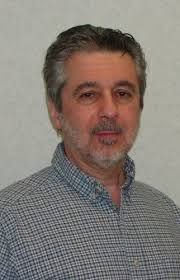

## principles

- accuracy of quantitative representation
- visual estimation of *differences*

## perceptual experiments

- show participants the same data in different formats
- ask them questions about relative magnitudes

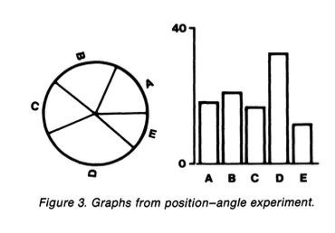

## perceptual experiments: results

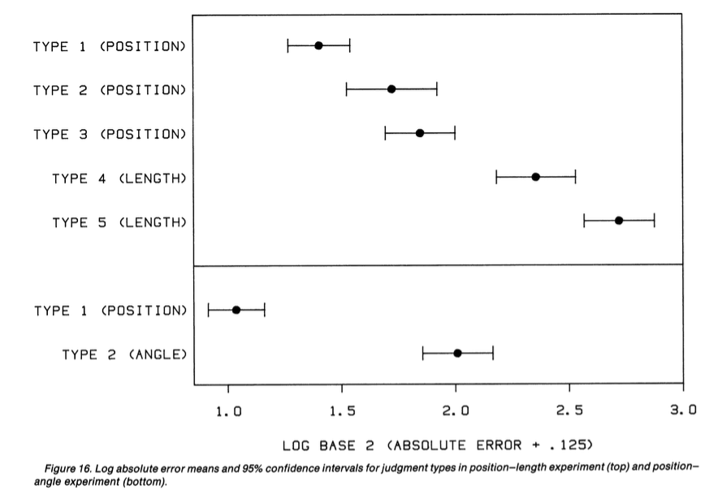

## is Cleveland still relevant?

- yes!
- Elliott (2016), “39 studies about human perception in 30 minutes”
  - healthy tradition of scientific experiments on graphical perception
    - accuracy
    - memory
    - preference

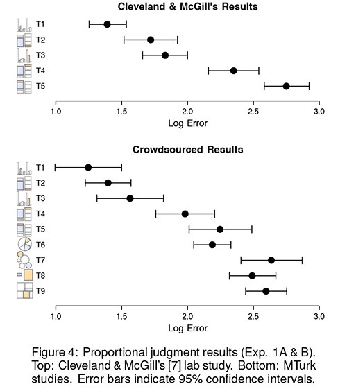

Heer et al. (2010)

# Edward Tufte

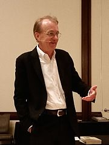

## Tufte principles

- functional, minimal graphics
- maximize data-ink / minimize non-data-ink
- small multiples (= trellis/lattice, facets, panels)
- “As for a picture, if it ain’t worth 1000 words, the hell with it” - [Ad Reinhardt](https://aphelis.net/how-look-reinhardt/)
- information at the point of need

“Understand that Tufte’s ideas are a good starting point, not a religion” ([Robert Kosara](https://eagereyes.org/criticism/edward-tufte-one-day-course))

## data ink

```
g0 <- (ggplot(OrchardSprays,
              aes(x = treatment, y = decrease))
  + scale_y_log10()
)
pg0 <- plot_grid(g0 +
             geom_boxplot(fill = "gray") +
             ggtitle("standard boxplot"),
          g0 +
             geom_tufteboxplot(stat="boxplot") +
             ggtitle("Tufte 'boxplot'")
          )
```

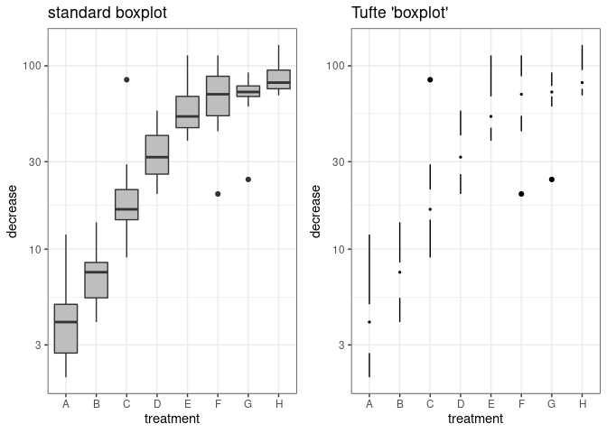

## information at the point of need

- less eye movement is better
- direct labels > legends > info in caption > info in text

```
g1 <- (ggplot(penguins,
              aes(x = bill_length_mm, y = bill_depth_mm,
                  colour = species, shape = species))
  + geom_point()
  + scale_colour_colorblind()
)
pg1 <- plot_grid(g1 + ggtitle("usual legend"),
                 direct.label(g1) +
                 ggtitle("direct labeling"))
```

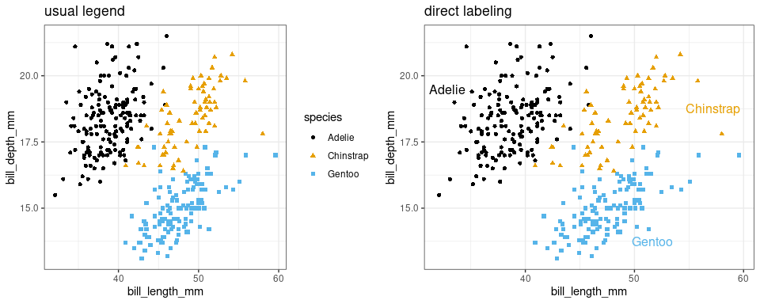

## direct labeling

- manually **if necessary**
- `directlabels` package
  - variety of labeling choices, e.g. `last.bumpup`: “Label last points, bumping labels up if they collide”
  - [documentation](https://tdhock.github.io/directlabels/)
  - `geom_dl()` for finer control
- also `ggrepel` (auto-repelling text labels)

## localize the most important contrasts

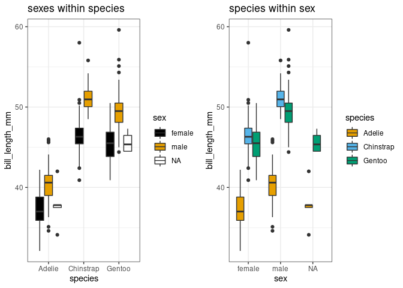

## and by island (faceting)

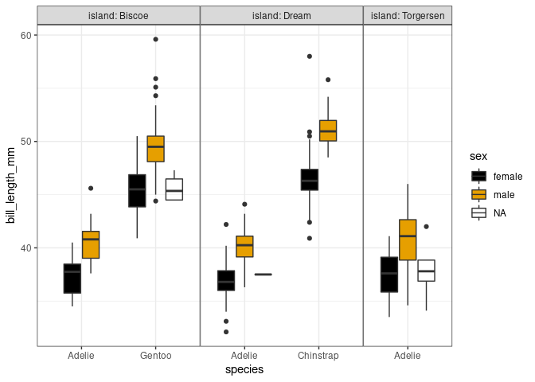

## Data presentation scales with data size

| data.size | approach | method |
| --- | --- | --- |
| small (1-20) | show all points (possibly dodged/jittered) | **categorical**: points, dotplot, beeswarm; **continuous**; points + line |
| medum (10-50) | robust summaries; show appropriate detail, downweight outliers | **categorical**: boxplot; **continuous**: loess, GAM, histogram |
| large (50+/group) | complex summaries; reveal patterns, ease computation | **categorical**: violins etc; **continuous**: density plots, hexbin |

## descriptive (points)

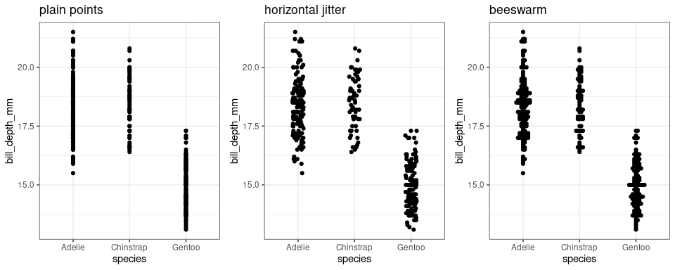

## descriptive (boxes/violins)

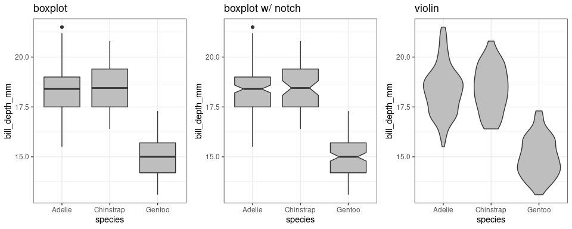

## inferential

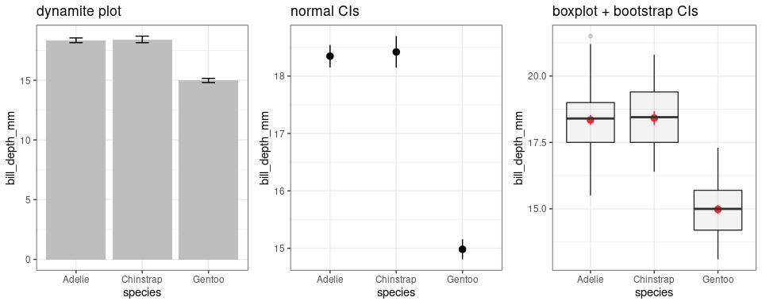

## binomial/binary data

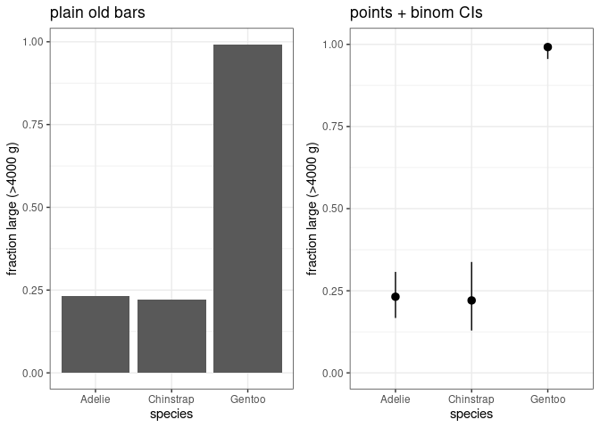

## Likert (ordered categorical) data

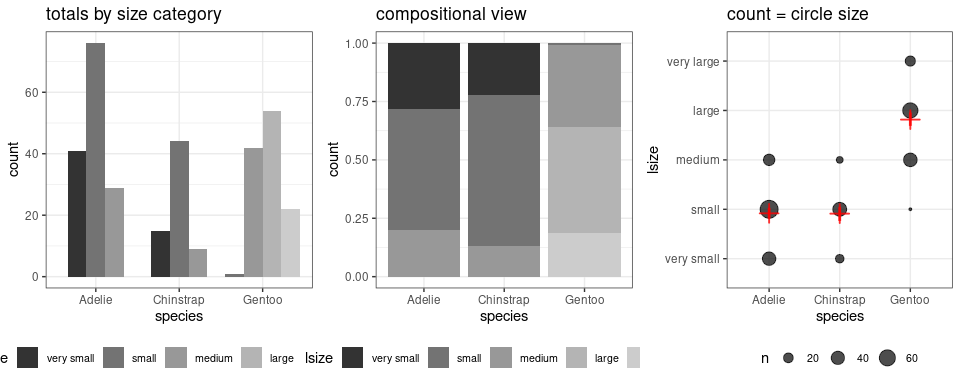

## ggplot extensions https://exts.ggplot2.tidyverse.org

[figure not shown]

## Esquisse

(demonstrate)

## References

Elliott, K. 2016.. *Medium*. https://medium.com/@kennelliott/39-studies-about-human-perception-in-30-minutes-4728f9e31a73.

Heer, J et al. 2010.. In *Proceedings of the SIGCHI Conference on Human Factors in Computing Systems*, 203–212. ACM.

Rauser, J. 2016.. https://www.youtube.com/watch?v=fSgEeI2Xpdc.

Wilke, CO. 2019. *Fundamentals of Data Visualization: A Primer on Making Informative and Compelling Figures*. 1st edition. Sebastopol, CA: O’Reilly Media.

Course home page